# 218235 Analysing Data Report

*N* removed NAs: 3

*N* removed typo: 1

*N* removed <18: 29

*N* total clean: 117

| Group | *N* | *M*<sub>age</sub> | *M*<sub>rating</sub> |
| --- | --- | --- | --- |
| Control | 57 | 21.1 | 5.12 |
| Experim | 60 | 21.0 | 6.11 |

**Main analysis results**

*t*(115) = -6.33, *p* < .001

[interactive chart not shown]

[figure not shown]

[interactive chart not shown]

# 218235 Analysing Data Report

Analysing Data, Spring 2020

# Methods

## Participants

Initially, this study’s participants were 150 females. However, a total of 33 participants’ data was removed, as they either had one or more pieces of missing data (NAs), or their reported age was under 18, and it would have been unethical to keep their data (as they could not give informed consent). The resulting number of participants was 117. Their ages were between 18-28, with a mean of *M*<sub>age</sub> = 21.09, and standard deviation of 2.34 years (rounded to two decimal place).

```
## # A tibble: 1 x 4
##   Mean_Age SD_of_Age Min._Age Max._Age
##      <dbl>     <dbl>    <dbl>    <dbl>
## 1     21.1      2.34       18       28
```

**Figure 01.** A summary table of the ages of all the participants.

```
## # A tibble: 1 x 4
##   Mean_Age SD_of_Age Min._Age Max._Age
##      <dbl>     <dbl>    <dbl>    <dbl>
## 1     21.1      2.56       18       28
```

**Figure 02.** A summary table of the ages of the participants in the control (white border) condition.

```
## # A tibble: 1 x 4
##   Mean_Age SD_of_Age Min._Age Max._Age
##      <dbl>     <dbl>    <dbl>    <dbl>
## 1     21.0      2.13       18       28
```

**Figure 03.** A summary table of the ages of the participants in the experimental (red border) condition.

## Design

In this study, the researcher examined the impact the colours red and white have on women’s perception of a man’s attractiveness. This was done by placing a 4inch by 6inch black-and-white (to minimise the effect of the colours of the photo itself) photo of a moderately attractive man (from a standardised photo set) in the centre of a 8.5inch by 11inch page. The colours investigated were placed on the area sorrounding the photo on the page. The man’s attractiveness was measured using three questions, which the women had to answer with a rating between 1 (not at all attractive) to 9 (extremely attractive). The scores from these answers were then averaged (for each participant) to create a composite score (this indicates perceived attractiveness). The questions asked were the following : How attractive do you think this person is? How pleasant is this person to look at? If I were to meet the person from this picture face to face, I would think he is attractive.

So, the researchers investigated whether the coloured border (red or a neutral white) of a (black-and-white) picture of a moderately attractive man impacted how women rated his perceived attractiveness. In order to test whether any correlation between the colour of the border and perceived attractiveness (if any is found) is significant, a *t*-test will be used.

# Results

Before analysis, the data was changed in the following ways: any rows (participants) with any number of missing data (NAs) were removed, participants with a reported age of under 18 were also removed, and the names of the conditions were changed from ‘control’ and ‘experimental’ to ‘White Border’ and ‘Red Border’ respectively. The resulting data had 57 participants’ data in the control group, and 60 in the experimental group.

The composite score of each of these groups was calculated. This was done by first calculating the mean rating score (from 1 to 9) of the 3 attraction questions for each participant (each separate ID). This mean rating was added to the other mean ratings in their condition. The total was divided by the amount of participants in each condition, to give the composite score. This was 5.12 for the control condition, and 6.11 for the experimental condition. A comparison of these means can be seen below.

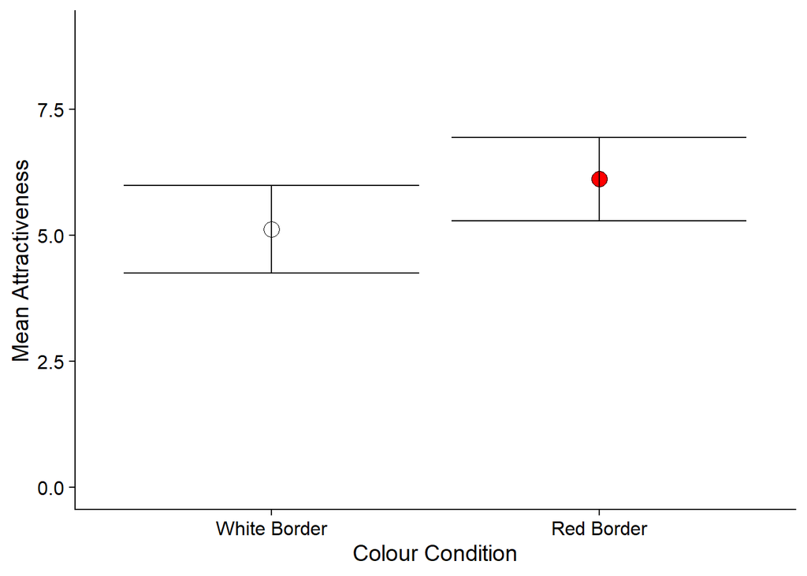

**Figure 04.** A comparison of the composite scores of each condition (+/- 1 Standard Deviation).

From this graph, it is clear that participants in the experimental group generally gave the man in the photo a larger mean perceived attractiveness rating. However, their mean composite scores overlap within one SD (standard deviation), so the correlation may not be as strong as initially perceived. This pattern continues with the maximum and minimum composite scores, as the control condition’s minimum score is 3.33, lower than the experimental condition’s 4.00, and control condition’s maximum score was 7.33, slightly lower than experimental condition’s 7.67. The conditions’ standard deviations are similar to each other (0.87 and 0.83), suggesting that the condition’s data was similarly spread, and are similarly reliable. A summary table with details on each conditions’ composite scores can be seen below.

```
## # A tibble: 2 x 5
##   CONDITION    Mean_Comp._Score    SD Min._Comp._Score Max._Comp._Score
##   <fct>                   <dbl> <dbl>            <dbl>            <dbl>
## 1 White Border             5.12 0.874             3.33             7.33
## 2 Red Border               6.11 0.825             4                7.67
```

**Figure 05.** A summary table of mean composite scores of each condition.

In order to test this apparent pattern, a *t*-test was applied to the data from this study. The difference between the mean scores of the conditions is *M*<sub>diff</sub>=-0.99. The *t*-test indicated that this difference is 6.33 (*t*=-6.33) times greater than the standard error of the difference in the means. The *t*-test also showed the p value to be less than .001 (*p*<0.001), and 95% CI [-1.31, -0.68]. This result states that the difference between the mean composite scores is significant, suggesting that the colour of the border affected the difference in means (they were not the result of random variations in perceived attractiveness ratings). An alternative hypothesis should be accepted (the coloured border did have an impact on perceived attractiveness, with either the colour red increasing it, or white decreasing it), and the null hypothesis rejected.

# Discussion

This study’s results have shown that there is a clear correlation between perceived attractiveness of a male in a photograph, and the colour context in which they are presented to women (red or neutral white border). The red colour likely unconsciously impacted the attractiveness of the man. However, colour is likely not the biggest contributor to perceived attractiveness, and other factors, such as facial symmetry (Little, Jones, & Debruine, 2011), are also important in attraction, and the average composite score between the two conditions only varied by around *M*<sub>diff</sub>=0.99 points on a 1-9 rating scale. This data has the same pattern of results as the original study Elliot et al. (2010), though the differences between the two means are slightly smaller than the ones in the original study. This implies that the correlation between the colour red and the attractiveness of a man (to a woman) is valid, but perhaps it is not as significant as some researchers may theorise, as both differences between the means were quite small compared to their rating scale.

However, other replications have not found a similar effect. Hesslinger, Goldbach, & Carbon(2015)’s replication, found that rather than the colour, the man’s attire had a stronger correlation with attraction (formal attire being seen as more attractive). This replication also had more ecological validity than the study here, which not only had a small sample size (compared to its replication), but also used college undergraduates, whose responses may not necessarily reflect such a wide-spread experience as perceiving attractiveness. It is noteworthy to point out that this study’s participants had the mean age of 21.09, and most of this sample were between the ages of 18 and 23 (within one SD). This is hardly representative of all women. In fact, since one of the theories as to why red is associated with higher perceived attractiveness of men is that it is associated with a higher status (Elliot et al, 2010), in order to test this phenomena, it could be crucial to test its effectiveness on older women (who tend to be more established, and tend to have more money than young students), and to see whether the woman’s own status changes how strongly her perceived attraction to a man is affected by the colour red.

In accord to this idea, many researchers have investigated whether women have a weaker preference towards men with greater earning capacities in countries that have greater gender equality (where women have greater earning capacities themselves). The results appear mixed, with some researchers finding a pattern, but replications (such as Zhang, Lee, Debruine, & Jones, 2019), finding no significant correlation, when controlling for Galton’s problem and correcting for comparisons.

Although there is some that seems inherently innate about what affects attraction, this study, amongst others, does not investigate cultural factors that could affect the effect of the colour red. For example, in certain African cultures, red is seen as a symbol of death and mourning. Further research could investigate whether women’s own schema of the colour impacts how strongly her attraction is affected by the colour (even if participants from these cultures cannot be obtained), perhaps initially with conducting interviews or surveys, and then developing into observing which regions (and what they are associated with) of their brain are active (and how active) when seeing red images .

The main strength of this study was the picture used in it. Firstly, by using the same picture in both conditions, the researchers controlled for attractiveness differences between two different pictures. Unlike some other researchers, they used a picture from a database, and the picture was already standardised as being moderately attractive. This allowed the researcher to easily see any anomalies within their data (e.g. someone’s composite score being extreme, such as 1 or 9 out of 9), and possibly explore the participant’s reasons for giving an extreme score to a man with non-extreme attractiveness further, possibly leading to some interesting further research (although no extreme patterns of scores were seen in this particular sample). However, in further research the researcher could consider adding more pictures (a variety of different physical appearances, but with a similar average attractiveness rating), in order to control for a variety of preferences that could be affecting the given average attractiveness score.

Yet, seeing a person, in the same pose and the same lighting even for a few seconds, is completely unlike real life, which highlights another issue that this study has regarding its ecological validity. This is the one of the main limitations of the study, and many others in this field. Hence, the red-attraction effect may be much weaker in real life, where a lot of other factors are also constantly affecting attraction, such as the person’s mannerisms. This could be combated in further research by at least using a standardised (with an estimated attractiveness rating) video of a man (once again, from a database), against a red or neutral background.

Overall, this study’s findings support the theory that red has an impact on perceived attraction (when women judge men), but its findings are quite one-dimensional, and further research should be done to establish just how strong this effect is, and why it is seen in some samples, but not in others.

# References

Elliot, A. J., Niesta Kayser, D., Greitemeyer, T., Lichtenfeld, S., Gramzow, R. H., Maier, M. A., & Liu, H. (2010). Red, rank, and romance in women viewing men. Journal of Experimental Psychology: General, 139(3), 399–417. doi: https://doi.org/10.1037/a0019689

Elliot, A. J., & Maier, M. A. (2013). The red-attractiveness effect, applying the Ioannidis and Trikalinos (2007b) test, and the broader scientific context: A reply to Francis (2013). Journal of Experimental Psychology: General, 142(1), 297–300. doi:10.1037/a0029592

Hesslinger, V. M., Goldbach, L., & Carbon, C.-C. (2015). Men in red: A reexamination of the red-attractiveness effect. Psychonomic Bulletin & Review, 22(4), 1142–1148. doi:10.3758/s13423-015-0866-8

Little, A. C., Jones, B. C., & Debruine, L. M. (2011). Facial attractiveness: evolutionary based research. Philosophical Transactions of the Royal Society B: Biological Sciences, 366(1571), 1638–1659. doi: 10.1098/rstb.2010.0404

Object Retrieval. (n.d.). Retrieved April 29, 2020, from https://www.ucl.ac.uk/museums-static/objectretrieval/node/277

Zhang, L., Lee, A. J., Debruine, L. M., & Jones, B. C. (2019). Are Sex Differences in Preferences for Physical Attractiveness and Good Earning Capacity in Potential Mates Smaller in Countries With Greater Gender Equality? Evolutionary Psychology, 17(2). doi:10.1177/1474704919852921